# Project: Investigate a Dataset (Medical Appointments Data in Brazil)

## Research Question 4:- what impact does having a desiease has on appointment

```python
## Finding out the no of apointments missed and attended based on patients diseases

def segregateing_appointment_based_on_diseased_and_non_diseased(data_frame,no_of_rows_to_change,Columns_to_study):

    ## initialising the list with 0 for using it as a counter

    Result = [0,0,0,0]                                   ## Order of data --> with  disease (attended,not-attended) without diseases (attended,not-attended)

    for data in range(no_of_rows_to_change):                                    ## Dividng the age values in the group of attended or missed
        if(data_frame.iloc[data][Columns_to_study] == 1 and data_frame.iloc[data]['No-show'] == 1):
            Result[0] = Result[0] + 1

        elif(data_frame.iloc[data][Columns_to_study] == 1 and data_frame.iloc[data]['No-show'] == 0):
            Result[1] = Result[1] + 1

        elif(data_frame.iloc[data][Columns_to_study] == 0 and data_frame.iloc[data]['No-show'] == 1):
            Result[2] = Result[2] + 1

        elif(data_frame.iloc[data][Columns_to_study] == 0 and data_frame.iloc[data]['No-show'] == 0):
            Result[3] = Result[3] + 1

    return Result     ## returning the list of data of the age of people
                                                                      ## who missed or attended appointment
```

```python
## plotting the bar graphs for the data collected above

def plot_bargraph_new(case,data,parameters):
    %matplotlib inline

    plt.bar(range(len(parameters)),data)
    plt.xticks(range(len(parameters)),parameters)
    plt.ylabel(case)
    plt.xlabel("Fraction of people enrolled or not")
    plt.title("No of Patients " + case)
    plt.show()
```

```python
## Creating a result generation and formating function


def Generate_result(data_frame,no_of_rows_to_change,Columns_to_study,Heading,parameters):

    data_based_on_enrolement = segregateing_appointment_based_on_diseased_and_non_diseased(data_frame,no_of_rows_to_change,Columns_to_study)

    ## Printing the no of people who have joined the welfare Scheam
    print("Percentage of " + Heading + " = {}% \n".format((((data_based_on_enrolement[0]+ data_based_on_enrolement[1]) * 100)/Data_size_limit)))

    print("Patients having " + Heading +" \n\nRercentage of Patients missed appointment = {}%\nPercentage of Patients attended appointment = {}%\n"
     .format(((data_based_on_enrolement[1]*100)/(data_based_on_enrolement[0]+ data_based_on_enrolement[1])),((data_based_on_enrolement[0]*100)/(data_based_on_enrolement[0]+ data_based_on_enrolement[1]))))

    print("Patients not having " + Heading +" \n\nRercentage of Patients missed appointment = {}%\nPercentage of Patients attended appointment = {}%\n"
     .format(((data_based_on_enrolement[3]*100)/(data_based_on_enrolement[2]+ data_based_on_enrolement[3])),((data_based_on_enrolement[2]*100)/(data_based_on_enrolement[2]+ data_based_on_enrolement[3]))))

    ## Drawing the graph for the result

    plot_bargraph_new('Attended/missed based on '+ Heading +' factor',data_based_on_enrolement,parameters)
```

```
Percentage of Hipertension = 19.72459218109602%

Patients having Hipertension

Rercentage of Patients missed appointment = 17.301958625751112%
Percentage of Patients attended appointment = 82.69804137424889%

Patients not having Hipertension

Rercentage of Patients missed appointment = 20.903680995424114%
Percentage of Patients attended appointment = 79.09631900457589%
```

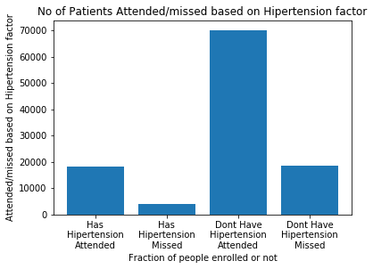

```python
## Printing the Result for different parameters

## Generating Results for patiens with Hipertension
parameters = ['Has\nHipertension\nAttended','Has\nHipertension\nMissed','Dont Have\nHipertension\nAttended','Dont Have\nHipertension\nMissed']

Generate_result(Appointment_data,Data_size_limit,'Hipertension','Hipertension',parameters)
```

### Infrence derived from the results of the above analysis are

- Here we notice that around 20% of patients suffer from hyper tension and they tend to attend appointment 82% times
- Hence it is as expceted that the patients with a diseas tend to attend appointments more

```
Percentage of Diabetes = 7.186479321794675%

Patients having Diabetes

Rercentage of Patients missed appointment = 18.00327332242226%
Percentage of Patients attended appointment = 81.99672667757774%

Patients not having Diabetes

Rercentage of Patients missed appointment = 20.362824612025268%
Percentage of Patients attended appointment = 79.63717538797474%
```

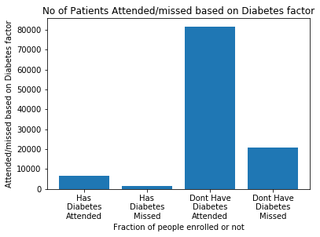

```python
## Generating Results for patiens with Diabetes

parameters = ['Has\nDiabetes\nAttended','Has\nDiabetes\nMissed','Dont Have\nDiabetes\nAttended','Dont Have\nDiabetes\nMissed']


Generate_result(Appointment_data,Data_size_limit,'Diabetes','Diabetes',parameters)
```

## Infrence derived from the results of the above analysis are

- Here we notice that around 7% of patients suffer from Diabetes and they tend to attend appointment 82% times
- Hence it is as expceted that the patients with a diseas tend to attend appointments more

```
Percentage of Alcoholism = 3.039981181068879%

Patients having Alcoholism

Rercentage of Patients missed appointment = 20.148809523809526%
Percentage of Patients attended appointment = 79.85119047619048%

Patients not having Alcoholism

Rercentage of Patients missed appointment = 20.194649472318904%
Percentage of Patients attended appointment = 79.8053505276811%
```

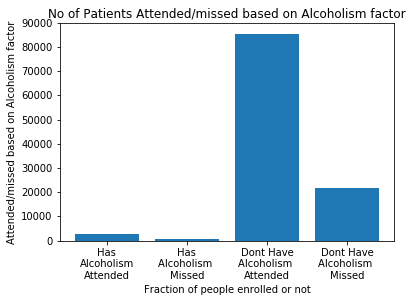

```python
## Generating Results for patiens with Alcoholism

parameters = ['Has\nAlcoholism\nAttended','Has\nAlcoholism \nMissed','Dont Have\nAlcoholism \nAttended','Dont Have\nAlcoholism \nMissed']



Generate_result(Appointment_data,Data_size_limit,'Alcoholism','Alcoholism',parameters)
```

```
Percentage of Handcap = 1.8475123725424556%

Patients having Handcap

Rercentage of Patients missed appointment = 17.92360430950049%
Percentage of Patients attended appointment = 82.07639569049951%

Patients not having Handcap

Rercentage of Patients missed appointment = 20.235302809227417%
Percentage of Patients attended appointment = 79.76469719077258%
```

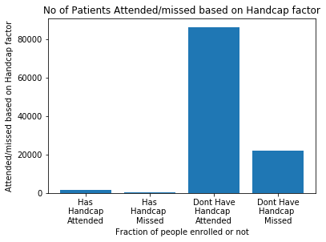

```python
## Generating Results for patiens with Handcap

parameters = ['Has\nHandcap\nAttended','Has\nHandcap \nMissed','Dont Have\nHandcap \nAttended','Dont Have\nHandcap \nMissed']


Generate_result(Appointment_data,Data_size_limit,'Handcap','Handcap',parameters)
```

## Infrence derived from the results of the above analysis are

- Here we notice that around 1.84% of patients suffer from Handicap and they tend to attend appointment 82% times
- Hence it is as expceted that the patients with a diseas tend to attend appointments more

```
Percentage of SMS_received = 32.10256317460892%

Patients having SMS_received

Rercentage of Patients missed appointment = 27.574544839637%
Percentage of Patients attended appointment = 72.425455160363%

Patients not having SMS_received

Rercentage of Patients missed appointment = 16.703311346525417%
Percentage of Patients attended appointment = 83.29668865347458%
```

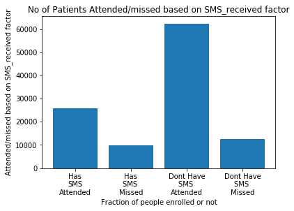

```python
## Generating Results for patiens who recieved nSMS

parameters = ['Has\nSMS\nAttended','Has\nSMS \nMissed','Dont Have\nSMS \nAttended','Dont Have\nSMS \nMissed']



Generate_result(Appointment_data,Data_size_limit,'SMS_received','SMS_received',parameters)
```

## Infrence derived from the results of the above analysis are

- **Here we notice that around 32% of patients recieve SMS and they tend to attend appointment 72% times**
- **while patents who dont get SMS tend to attend 83%of times**
- A valid reason can be that the **Patients getting sms are high priority Patients who may not able to attend their appointments on time due to some illness issue.**
- Or may be people dont **read sms most of the time.**
- General population without getting sms performs better may be due to many factors one be the Patients with high priority might be to ill to attend appointment so they might get treatement at home

## Conclusions

### Limitations

- The different categories (Columns) Provided in this data set do not provide sufficent information to derive the exact reason behind the behaviour of the patients towards attending or missing the appointment.
- We observe a **anamolous behviour when we study the patients who recieve SMS miss their appointment often. Now we cannot get to the exact cause of this scenario due to limitation of the data set as it does not discss to whom the sms are sent like is it for older people, for premium clients , or for those who require special medical attention etc**.
- Similarly along with the location of neighbouthood of the hospitals **if information like rural,Urban area was provided it could have made it more easier to understand the trendas we saw in the analysis above that most hospitals have large no of patients attending as well as missing (Here we can assume such hospitasl are more accessable) but cannot strengthen our analysis due to limitation of the information set of the data**
- **Here very selected deseases are mentioned in the data which should have been more elaborated and common disease like flu etc should be menitoned that would have helped us get the deeper insight to understand the trends and patterns well**

## References

- Pyhon Documentation [Link](https://docs.python.org/3/contents.html)
- Numpy Documentation [Link](https://docs.scipy.org/doc/numpy/user/basics.creation.html)
- Stack Overflow [Link](https://stackoverflow.com/)
- MatplotLib Documenation [Link](https://matplotlib.org/index.html)
- CheatSheet [Link](https://storage.googleapis.com/supplemental_media/udacityu/5435548805/numpy_pandas_cheatsheet.pdf)